# 如何烘焙 π · How to Bake Pi — Eugenia Cheng

## 5 推广Chapter 5 Generalization

### 橄榄油李子蛋糕Olive Oil Plum Cake

#### 配料Ingredients

2—4 个李子

2–4 plums

1 个鸡蛋

1 egg

4 盎司杏仁粉

4 oz. ground almonds

3 盎司龙舌兰糖浆或枫糖浆

3 oz. agave or maple syrup

#### 做法Method

1. 将李子切成较薄的片，切面朝下，在铺有烘焙纸的蛋糕模底部摆成漂亮的图案。

1. Slice the plums quite thinly and arrange them cut face down in a pretty pattern on the bottom of a cake pan lined with parchment.

2. 将其余配料搅打均匀，轻轻倒入模中，覆盖在李子上。

2. Whisk the rest of the ingredients together and pour gently into the pan over the plums.

3. 以 350°F 烘烤 20 分钟，或烤至金黄且凝固。

3. Bake at 350°F for 20 minutes or until golden and set.

4. 倒扣脱模，让李子朝上。

4. Turn out upside down so the plums are on top.

如果你发明过食谱，你就会知道你需要先从一本食谱书，或是互联网上的一个既有食谱着手，然后根据你自己的喜好、一时兴起或过敏症来调整这个食谱。也就是说，你会从一个你熟悉和喜欢的情形入手，看看你能对它做些什么改变，让它变得稍有不同——或者变得更好。

If you’ve ever invented a new recipe, you might well have started with one from a book, or online, and modified it to your own tastes, whims, or allergies. That is, you start with a situation you know and love, and see what you can do that’s a bit similar but different—and maybe even better.

我小的时候对食用色素过敏，因此我的父母出于对我的爱研究出了如何在不使用那些可爱（或可怕）的色彩鲜艳的果冻粉的前提下制作果冻。长大后，我开始跟某个对小麦过敏的人约会，于是我为他发明了很多不含小麦粉的甜点食谱。（相比之下，做不含小麦粉的主菜更容易一些。）再后来，我开始减少糖的摄入量，而我的一些朋友开始避免摄入奶制品……现在，常有人抱怨在给朋友做饭的时候，太多人有各种奇怪的饮食限制，这让做出适合所有人口味的饭菜几乎是不可能的。如果你也面临这样的问题，那么你有这样几个选择：你可以拒绝邀请他们来吃饭，你可以想做什么做什么，彻底忽略他们的饮食喜好，你可以请他们自带食物，或者，你也可以直面挑战，在遵循每个人的饮食限制的前提下，做出适合所有人的食物。

When I was little I was allergic to food coloring, so my parents lovingly worked out how to make fruit gelatin from scratch instead of from the appealingly (or appallingly) brightly colored Jell-O packets. Later, I was dating someone allergic to wheat, so I invented a lot of wheat-free desserts. (It’s a bit easier to make wheat-free main courses.) Later on I started avoiding sugar, and I had other friends who were avoiding dairy. . . . A modern complaint about cooking for friends is that so many people are following strange restrictive diets that it’s impossible to cook for all of them at once. If you’re faced with such friends you have several choices. You can refuse to invite them for dinner, you can ignore their dietary preferences and cook whatever you like, you can ask them to bring their own food, or you can rise to the challenge.

我发明这个橄榄油李子蛋糕的初衷就是做出让来参加聚会的坚持无麸质饮食、无奶制品饮食、无糖饮食以及坚持原始人饮食法的各位朋友都能吃的蛋糕。当时，唯一不能吃这个蛋糕的是一位在那段时间里坚持只吃西葫芦和印度酥油的客人。每个人都表示蛋糕很美味，但当他们问我这种蛋糕叫什么名字的时候，我却回答不出来，因为它并不是传统意义上的“蛋糕”，只能算作一种广义上的蛋糕。它和蛋糕有很多共通之处：它看起来像蛋糕，做起来像蛋糕，扮演蛋糕的角色，但仍然不完全是蛋糕。在一个普通蛋糕不适用的情境里，它解决了我面临的困境。

I invented the olive oil plum cake to be gluten-free, dairy-free, sugar-free, and paleo-compatible. The only party guest who couldn’t have it was the one who was at that time only eating zucchini and ghee. Everyone said it was delicious, but when they asked me what it was I didn’t know what to call it, because it’s not really a cake—it’s a *generalization* of a cake. It has things in common with a cake, looks like a cake, is made like a cake, plays the role of a cake, but is still somehow not quite the same as a cake. It is useful in situations that an ordinary cake would not be able to handle.

这就是数学中“推广”（generalisation）这个概念的意义——你从一个你熟悉的情境出发，对其稍加改动，使其可以应用于更多的其他情境。这个概念之所以被称为“推广”是因为它对某个概念的内涵进行了扩充，于是，“蛋糕”这一概念就可以将一些近似蛋糕但并不完全是蛋糕的其他食物囊括在内。这并不等于笼统的陈述，那是这个词的另外一种用法，我们在后文中会再次探讨这个问题。

This is the point of generalization in mathematics as well—you start with a familiar situation, and you modify it a bit so that it can become useful in more situations. It’s called a generalization because it makes a concept more general, so that the notion of “cake” can encompass some other things that aren’t exactly cakes but are close. It’s not the same as a sweeping statement, which is a different use of the word, as we’ll see later.

一个关于推广的例子是我们如何从全等三角形推广到相似三角形的。全等三角形指的是完全一样的两个三角形——它们的内角度数、边长全都相同，也就是说，它们的“形状”和“大小”完全一样，如下图所示：

One example of generalization is where we move from *congruent* triangles to *similar* triangles. Congruent triangles are ones that are exactly the same—they have the same angles and the same lengths of sides. That is, they’re the same “shape” and the same “size.”

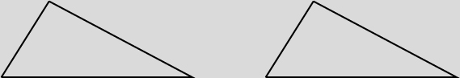

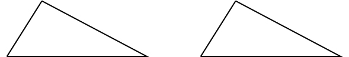

而相似三角形只需要两个三角形“形状”相同即可，并不要求“大小”相同，也就是说，它们的内角度数是一样的，但边长一样这个条件被去掉了。

For *similar* triangles we only demand that they’re the same shape, not necessarily the same size. That is, they still have to have the same angles, but we drop the rule about having the same lengths of sides.

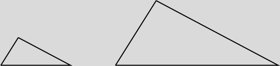

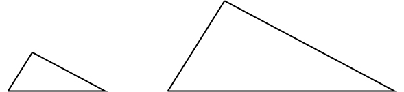

因为我们去掉了一个条件，让规则变得更宽松了，所以现在有更多对三角形符合这个条件，而与此同时，它们仍然有别于随机出现的一对三角形。

Because we’ve relaxed a rule, there are now more triangles that satisfy these conditions, but it still isn’t total anarchy.

### 无面粉巧克力蛋糕Flourless Chocolate Cake

#### 通过省略来创造Inventing Things by Omission

假设我们希望“证明”这件事：你必须把水烧开，然后才能拿它来泡茶。你也许会试着用未烧开的水来泡茶，然后你可能发现这次的茶很难喝（或者根本喝不出味道），于是你下结论说：是的，你的确需要把水烧开才能泡茶。  
或者，你可能希望“证明”这件事：你需要为汽车加汽油才能驱动汽车前进。你试着启动油箱已空的汽车，发现无法启动。于是你下结论说：你的确需要为汽车加汽油才能驱动汽车前进。

Imagine trying to “prove” that you really need to boil water to make tea. You would probably just try to make tea without boiling the water. You discover that it tastes disgusting (or has no taste at all) and conclude that yes, you do need to boil water to make tea. Or you might try to “prove” that you need gas to make your car go. You try running it on an empty tank and discover it doesn’t go anywhere. So yes, you do need gas to make your car go.

在数学里，这种证明方法被称为“反证法”——做与待证结论相反的事，然后证明在这种情况下你会得到完全错误的结果，于是得出待证结论是正确的这一判断。

In math, this is called *proof by contradiction*—you do the opposite of what you’re trying to prove, and show that something would go horribly wrong in that case, so you conclude that you were right all along.

这里有一个关于反证法的小例子。假设n是一个整数，并且n2是奇数。我们要证明的是：n必须也是奇数。

Here’s an example of a small proof by contradiction. Suppose *n* is a whole number and *n*<sup>2</sup> is odd. We’re going to prove that *n* has to be odd as well.

现在我们假设结论的反面是真的，即假设n2是奇数，但n是偶数。然而，一个偶数乘以一个偶数总会得到偶数，这就会让n2成为偶数。而这与n2为奇数的前提相矛盾。因此，我们之前的假设是错误的。也就是说，原假设中n为奇数的结论一定是真的。

We begin by assuming the opposite is true, so we suppose that *n*<sup>2</sup> is odd, but that *n* is even. However, an even number times an even number is always even, so this would make *n*<sup>2</sup> even. This contradicts the fact that *n*<sup>2</sup> was supposed to be odd, so we must have been wrong to assume the opposite. Therefore, the original statement that *n* is odd must be true.

有时，反证法并不能让人满意，因为它并没有解释为什么一件事是真的，它只解释了为什么一件事不可能是假的。我们在后文中会反过来继续探讨这个关于“富有启发性的”和“无启发性的”证明之差别的问题，以及某件事如果不假必然为真这个预设。

Sometimes proof by contradiction can be very unsatisfying because it doesn’t really explain why something *is* true—it just explains why something *can’t be false*. We’ll come back to this later when we talk about the difference between “illuminating” and “unilluminating” proofs, and the background assumption that if something isn’t false then it must be true.

一个更有名、更长的反证法案例是关于√2是无理数的证明，即证明√2不能被写成分数a/b（其中a和b为整数）这一形式。你也许知道√2=1.4142135…，并且它的小数位“无限不循环”，这些要素都是无理数的特点，但并不能作为一种证明。以下是我们的证明过程。

**证明：**我们假设待证结论为假，因此我们假设存在两个整数a和b使得√2＝a/b。关键在于，我们在这里需要同时假设这个分数是最简分数，也就是分子和分母没有除1以外的公因数使得该分数可以被约简。

现在我们分别把等式两边取平方，得到：

*Now we square both sides to get*

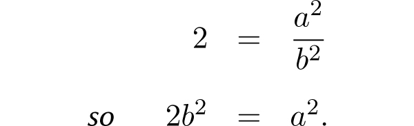

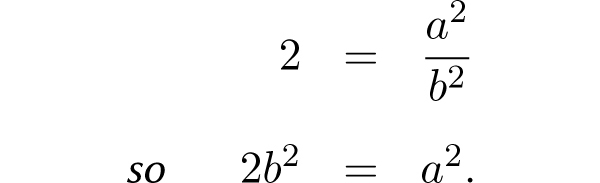

目前为止，一切看起来简单明了。现在我们知道的是，a2是某个数字的两倍，也就是说它是一个偶数。因此a必须也是偶数，因为我们刚刚证明过，如果a是奇数，则a2也是奇数。

*So far so good. Now we know that a*<sup>2</sup> *is two times something, which means it is an* even *number. This means that a has to be an even number as well, because if a were odd then a*<sup>2</sup> *would also be odd.*

那么，a是偶数意味着什么呢？意味着它可以被2整除，也就是说a/2仍然是一个整数。所以我们可以说：

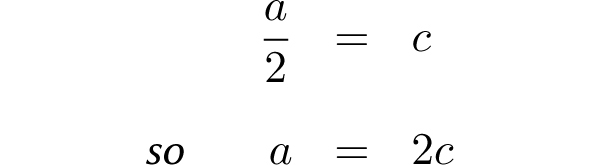

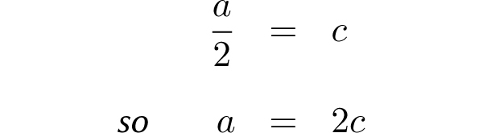

现在把上面这个等式代入之前的等式，得到：

*and now substitute that into the equation above, so we get*

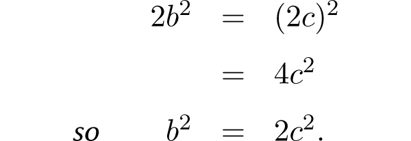

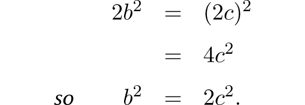

现在我们可以用之前证明a为偶数的方法来证明b也为偶数。从上面这个等式中，我们可以看出b2是某个数字的两倍，所以它是一个偶数，也就是说b一定是偶数。

*Now we can do the same reasoning on b that we just did for a. We know b*<sup>2</sup> *is two times something, so it’s even, which means b must be even.*

现在我们发现a和b都是偶数。但我们在最开始假设了a/b是一个最简分数，也就是说a和b不能都是偶数。如此，我们就发现了一个矛盾。

所以我们一开始的假设，√2=a/b是错的，也即√2不能被写成分数的形式，因此它是一个无理数。

反证法是一种非常有效率的证明方法，当数学家无法直接证明一个结论为真的时候，他们可能会将反证法作为万不得已的最后手段——证明待证结论不可能是假的。有时，反证法可能并不能达成你期待的效果。比如，也许你尝试证明做巧克力蛋糕必须用到面粉。于是你试着做了一个不含面粉的巧克力蛋糕，结果你发现味道也不错。实际上，你所做的事情是发明了一种全新的蛋糕：无面粉巧克力蛋糕，而这种蛋糕目前在许多高档餐厅十分流行。

Proof by contradiction can be very efficient, and mathematicians sometimes use it as a last resort when they can’t work out how to prove that something is true directly—they instead try to prove that it can’t be false. Sometimes that kind of proof doesn’t turn out the way you’re expecting it to. Maybe you try to prove that you really need flour to make a chocolate cake. So you make it without flour. . . and you discover that it’s really not that bad. In fact, you’ve invented a whole new kind of cake: the flourless chocolate cake, now popular in many fancy restaurants.

酵母和面包的关系也是如此。你也许希望证明做面包必须用到酵母。于是你尝试着做了不加酵母的面包，从而意外“发明”了无酵饼。

Likewise yeast and bread. You might try to prove (no pun intended) that you definitely need yeast to make bread. So you try making it without yeast—and you’ve “invented” unleavened bread.

类似的事情在数学里也会发生——一开始，你希望证明的是某件事是不可能的，最后却意外地发现它其实是可能的，虽然你得到的结果可能与待证结论稍有不同。这是推广的一种可能的方式，几乎完全出于偶然。符合此描述的最重要的一个例子发生在几何学领域，与平行线有关。

This can happen in mathematics as well. You set out to try and prove that something can’t be done, and you accidentally discover that it actually can, although maybe something slightly different results. This is one way that generalization can turn up, almost by accident. One of the most important examples of this is from geometry, involving parallel lines.

### 平行线Parallel lines

#### 欧几里得的天才The Genius of Euclid

在很久以前，欧几里得就尝试着总结出了几何学的规则。他的初衷是确定几何学的公理，即列出一张包含所有关于几何学的事实都可以据此推导出来的基本规则的简短清单。这些基本规则应该是一些最基本的事实，你无法想象它们可以由任何其他的事物推导出来——它们的真不证自明。

The story goes like this. Once upon a time Euclid set out to write down the rules of geometry. The idea was to axiomatize geometry, that is, write down a short list of rules from which all facts of geometry could be deduced. The idea is that your basic rules should be absolutely fundamental, things so basic that you can’t imagine deriving them from anything else—they simply *are true*.

不管怎样，欧几里得最终想出了4条非常简单而直观的规则，以及一条复杂到令人恼火的规则：

Anyway Euclid came up with four very simple and obvious-sounding rules, and one annoyingly complicated one. They went something like this.

1. 经过任意相异两点有且只有一条直线。

1. There’s exactly one way to draw a straight line between any two points.

2. 将一条线段延长为无限长的直线有且只有一种方法。

2. There’s exactly one way to extend a finite straight line to turn it into an infinitely long one.

3. 对于确定的圆心和半径有且只有一个圆。

3. There’s exactly one way to draw a circle with a given center and radius.

4. 所有的直角都相等。

4. All right angles are equal.

这些听起来都很直观，不是吗？再看看第五条：

Those sound quite obvious, don’t they? And then comes the fifth one:

5. 只要足够长，任意三条直线总会构成一个三角形，除非它们彼此垂直。

5. If you draw three random straight lines they will make a triangle somewhere, if you draw them long enough, unless they meet each other at right angles.

最后一条规则的意思是，如果三条直线彼此垂直的话，其中两条就是平行线，那么不管它们有多长，它们都不会相交。

The idea is that if your three straight lines meet each other at right angles, then two of them will be parallel, and no matter how long you draw them they will never meet up to form a triangle.

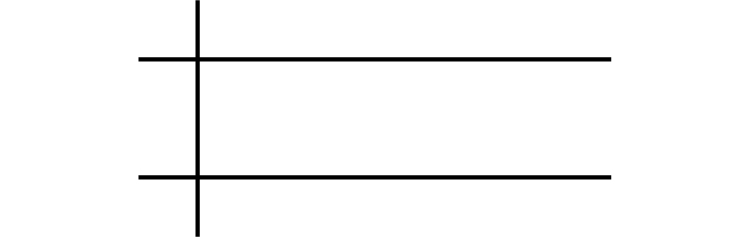

这就是为什么第五条规则也被称为“平行公设”，虽然它实际上并没有直接提及平行线这个概念。第五条规则也告诉了我们，三角形的三个内角之和总是180°。

This is why the fifth law is called the “parallel postulate” even though it doesn’t explicitly mention parallel lines. The 5th law is also what tells us that the angles of a triangle always add up to 180°.

第五条规则听起来比其他几条复杂很多，因而几百年来，很多人试图证明它是一条多余的规则，也即它可以由其他四条规则推导出来。大家都认同这条规则是正确的，唯一的分歧在于它是否需要这样被强调，是不是有了其他的规则，我们自然就能推导出这条规则，而不必特意多说一遍。

This last rule sounds so much more complicated than the others that people spent hundred of years trying to show it was redundant as a law, that is, that it could be deduced from the other four. Everyone knew it should be true, the only question was whether it needed to be enforced out loud, or whether it would automatically follow from the other laws even if you didn’t say it out loud.

为了证明这个判断，人们来回地兜圈子。偶尔，他们觉得自己已经用前四条规则推导出了第五条规则，但事实上他们总是在证明的过程中不小心用到了一些对他们而言不证自明，但实质上只不过是将第五条规则微妙地转换了形式的几何假设。所以，他们所做的不过是用第五条规则自身来证明第五条规则，算不上是多么石破天惊的发现。

People went round and round in loops and often thought they had proved it from the first four laws, when really they had accidentally used some assumption about geometry that seemed very obvious to them but was subtly equivalent to the fifth law. So, implicitly, they were *using* the fifth law to *prove* the fifth law—not that earth-shattering.

最后，大家决定用反证法来证明它。也就是说，他们先假设前四条规则是真的，最后一条是假的，然后尝试着在证明过程中发现矛盾。

In the end people decided to try to prove it by contradiction, that is, they assumed that the first four rules held but that the parallel postulate did not, and then set about looking for things that would go horribly wrong elsewhere.

有趣的事发生了，就像无面粉巧克力蛋糕一样，证明过程中矛盾没有出现，反而是一种新的不同的结论被发现了——他们发明了一种几何学的新形式。

And the funny thing was, like with the flourless chocolate cake, nothing ever went wrong. It was just different—they had invented a new form of geometry.

我们现在已经知道有两类几何情形不遵循平行公设。其中一种是球状物体的表面，比如球面或橄榄球表面，在该表面上，三角形内角之和大于180°。这种新的几何学形式也被称作椭圆几何。

We now know there are two types of geometry that don’t satisfy the parallel postulate. There’s the type where you imagine you’re on the surface of something round like a sphere or a football. Here, the angles of a triangle add up to *more* than 180°. This is called *elliptical geometry*.

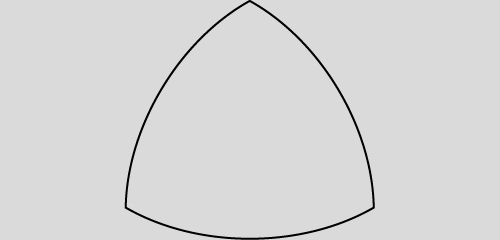

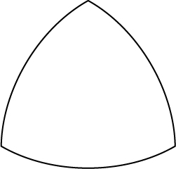

另一种情况是向内凹陷的曲状表面。在该表面上，三角形内角之和小于180°。这种新的几何学形式也被称作双曲几何。

The other type is where you imagine you’re on a surface curved the other way like the inside of a bowl. Here the angles of a triangle add up to *less* than 180°. This is called *hyperbolic geometry*.

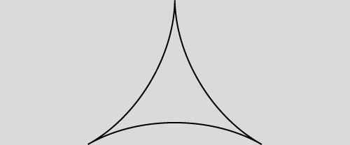

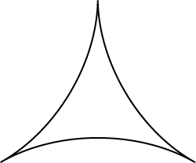

而最原始的平行公设成立于表面为平直表面的情形，这种数学情形就被称作欧几里得几何。

The original case where the parallel postulate does hold is like being on a flat surface, and is called *Euclidean geometry*.

### 出租车Taxicab

#### 对“距离”概念的推广Generalizing the Notion of Distance

在英语中，我们常用“像乌鸦一样飞”这个短语来表示走直线，但当你真的去旅行的时候，你就会发现走直线几乎是不可能的。因此，从A地到B地的距离通常取决于你准备怎么走。并且，这种选择也会影响距离远近对你的重要性。

We talk about distance “as the crow flies,” but when you’re actually traveling it’s unlikely you’ll ever travel as the crow flies—so the distance from A to B will change depending on how you’re traveling. How much you care about this will probably change too.

如果你准备坐火车前往目的地的话，你通常会在起点买好票，而且也不用考虑火车具体走了多远的距离这个问题。但如果你准备坐出租车前往目的地的话，你就会很在意整个路程到底有多远。要注意，我们讨论的不是两地间的直线距离，而是“出租车行驶的距离”。这件事会受到很多因素的影响，比如出租车司机会不会绕远。对此，我们最好假定出租车司机是诚实的，选择了最佳路线，就像我们假定乌鸦会飞直线而不会为了看风景绕路一样。但两者的主要区别在于，在当前这种情况下，出租车行进的距离还取决于一些额外的因素，比如是否经过单行道等，因此，适用于直线距离的原则就不再适用于出租车出行了。（也许有一天我们能发明出会飞的、可以走直线的出租车，但据我所知，目前我们还做不到。）

If you take a train, you usually buy your ticket at the beginning and then you don’t worry about exactly how far the train is going. But if you take a taxi, it really matters how far the taxi is going since you’re paying by the mile. However, instead of the distance as the crow flies, we’re thinking about the distance “as the taxi drives.” The trouble is this can be affected by matters such as: is the taxi driver going the long way round? So we’d better assume we have an honest taxi driver, just like we assume the crow is going to take the shortest route rather than some scenic detour. The important difference is that distance now depends on things like one-way streets, and suddenly the principles that are followed by crow-distance might not hold for taxi-distance. (Perhaps one day we’ll have flying taxis that will really take us as the crow flies, but not yet.)

举个例子，对于乌鸦来说，从A到B的距离等于从B到A的距离。但对于出租车而言，情况就未必如此了。比如，你坐出租车从单行道的一端开到另一端，就比你从另一端绕路回到这一端的距离要短很多。

Here’s an example. For a crow, the distance from A to B is the same as the distance from B to A. But this is not true for a taxi. For example if you hail the cab at one end of a one-way street and get it to take you to the other end, that will be a much shorter journey than when you try to go home again and have to go the long way round.

如果我在谷歌地图上查从谢菲尔德火车站到谢菲尔德市政厅的路线的话，我会得到这样的结果：

If I get directions on Google Maps between Sheffield train station and Sheffield town hall, I get this:

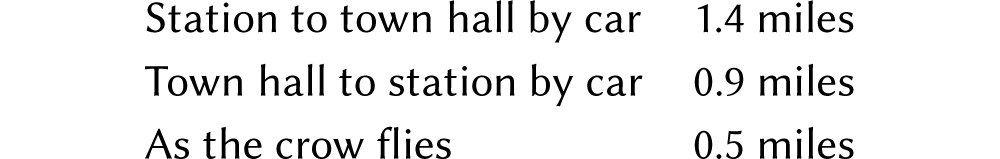

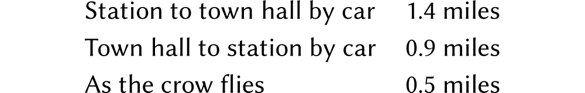

坐汽车从市政厅到火车站0.9英里  
直线距离0.5英里  
对于像伦敦这样的城市，人们很难计算出在乘坐出租车的情况下从A地到B地的距离，因为这类城市的单行道系统很复杂，道路曲折，而且你往往会因为担心出租车的费用过于昂贵而无法专心计算距离。所以我们这里以芝加哥为例，芝加哥的出租车行驶距离要容易计算得多，原因有如下几个：

In a place like Sheffield it’s quite hard to work out the taxi-distance from A to B, because the one-way system is complex, because the streets are so bendy, and because you’re so concerned about how expensive the whole thing is becoming you can’t really focus on distances. So let’s talk about Chicago, where it’s much easier to work out taxi-distance for several reasons:

1. 芝加哥的道路系统是网格状的，其道路又长又直，且彼此垂直。这是最主要的原因。

1. Mostly it’s a grid system, so the roads are all long and straight and meet at right angles.

2. 芝加哥的门牌号是以距离命名的，所以“5734号南”（芝加哥大学数学系的门牌号）就表示这个地址在0号以南多远，而不是说它是南面的第5734栋楼。我第一次知道这件事时惊叹极了。在已知每800号等于1英里的前提下，计算出租车需要行驶的距离就相对容易许多了。

2. The addresses are numbered according to distance, so “5734 South” (the house number of the Math Department of the University of Chicago) tells you how far south of zero the building is, not that it’s the 5734th building down. This blew my mind when it was first explained to me. 800 = 1 mile, so you can calculate relatively easily how far your taxi has to go.

3. 芝加哥的单行道系统比较合理，所以通常而言你不太需要绕路，只要你对这个系统足够熟悉，能在适当的时候转弯即可。

3. The one-way system is fairly sensible, so that it’s mostly possible to get where you’re going without doubling back on yourself too much, as long as you know the system and make your turns at well-timed moments.

4. 芝加哥的出租车价格比伦敦便宜很多，所以我不会因为担心费用昂贵而烦躁不安。

4. Taxis are much cheaper than in London, so I don’t get quite so worked up about how much it’s going to cost.

除了因为担心费用昂贵而心情烦躁以外，以上情形对于出租车和其他交通工具而言都是适用的。但我之所以拿芝加哥的出租车为例，是因为这是一个真实存在的数学概念，叫作“出租车几何”（taxicab metric）。也许是因为此类问题的确是数学家会在乘坐出租车时思考的问题吧，当他们使用其他的交通工具时，他们可能会更关注交通情况。我们正是通过探讨距离一类的概念应该具备哪些特质，才逐渐建立起度量这个概念的。

Aside from getting worked up about the cost, this doesn’t really depend on being in a taxi rather than any other kind of car. However, it is a genuine mathematical concept called the *taxicab metric*. It might be because it’s the kind of thing mathematicians think about when sitting in a taxi, whereas if they’re in a car one hopes they’re concentrating on the traffic. We are gradually building up to the notion of “metric,” by investigating what sorts of properties distance-like notions should have.

当然，芝加哥的道路系统并不是一个严格意义上的网格状系统，它还包括以对角线形式穿越整个网格系统的大型高速公路。但我们现在暂且不考虑对角线公路这一细节。我们会在下文中看到，丢掉一部分会带来麻烦的细节就是一种“理想化”，这对数学而言是一个很重要的环节。这件事可能会让人感到沮丧（毕竟对角线形式的高速公路是真实存在的），但这种做法的目的是理解某些事物的运作原理，而非建立一个精确的模型。我们现在的目标是解释清楚“距离”这个概念。

Of course, Chicago isn’t *precisely* a grid system at all times, and there are big highways that cut across the grid system at diagonals. So we’re throwing away the details about diagonals for the time being. Later we’ll see that this process of throwing away inconvenient details is a form of “idealization” that is a key part of mathematics. This can seem frustrating (there simply *are* diagonal highways in Chicago), but the point is to shed light on something rather than to model it precisely. Our aim now is to shed light on the notion of “distance.”

既然我们已经把芝加哥变成一个出租车行驶方便的、道路彼此垂直的“理想化的网格体系”，那么从A地到B地的出租车行驶距离就可以简化为：

Now that we’ve turned Chicago into an “ideal grid” that taxis drive across, making only right-angled turns, the taxi-distance from A to B is simply:

水平距离 + 垂直距离

Horizontal distance + Vertical distance

[figure not shown]

[figure not shown]

也就是说，无论出租车司机选取了怎样的路线，其整个行驶距离也不可能短于先一路横着开，再一路竖着开的行驶距离。即使我们在不同的路口转弯，比如像这样：

That is, no matter what clever route the taxi driver takes, it can’t get any shorter than simply driving all the way across first, and then all the way down afterwards. Even if we make the turns in different places, say like this:

[figure not shown]

[figure not shown]

整个行驶距离还是一样，因为我们不考虑转弯的时间。然而，如果我们以一种完全不合理的方式在中途来回转弯，那么整个行驶距离就会变长，比如像这样：

the distance is still the same, because we’re not taking into account the time it takes to turn a corner. However, it would be longer if we did something really bizarre, like this:

[figure not shown]

[figure not shown]

如果你还记得毕达哥拉斯定理的话，你也许会记得它告诉了我们如何计算一个直角三角形的斜边长度。在我们这个例子里，计算斜边的长度就相当于计算两地之间的直线距离。

If you remember anything about the Pythagorean theorem, you may remember that it tells us how to calculate the length of the diagonal edge of a right-angled triangle. In our case, that’s the distance as the crow flies.

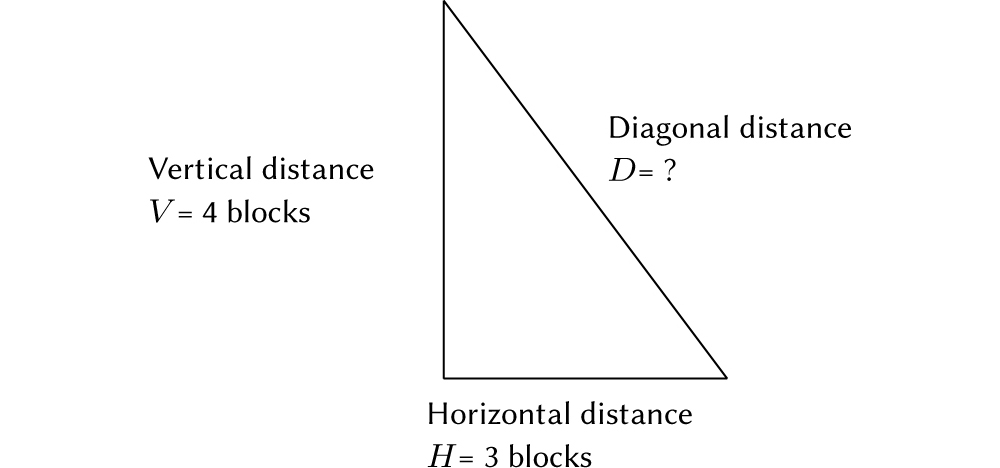

在毕达哥拉斯讨论的情形中，这条边叫作“斜边”。勾股定理指出：

In Pythagoras’s case, that’s called the “hypotenuse.” The Pythagorean theorem says

斜边的平方等于两个直角边的平方之和。

*The square of the hypotenuse is equal to the sum of the squares on the other two sides.*

将该定理应用于上图这个例子，则：

如此，我们就可以算出斜边，也就是两地间的直线距离D：

and we can work out that the diagonal, crow-flying distance is 5.

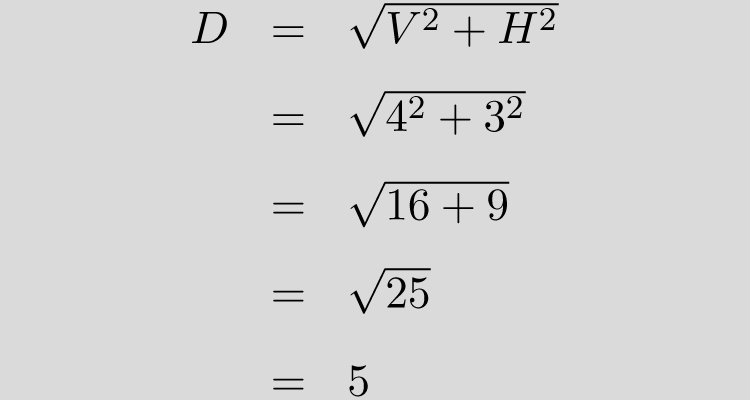

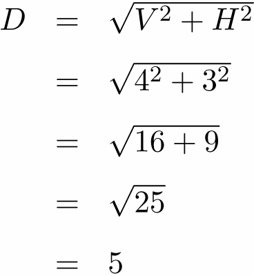

换句话说，乌鸦只需要飞5个街区的距离就可以从A地到达B地。而出租车需要行驶的水平距离加上垂直距离是：

The crow only has to fly the distance of 5 blocks. The taxi, however, has to go the vertical distance and the horizontal distance:

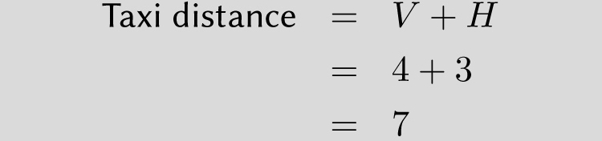

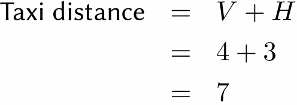

出租车距离=V+H  
也即出租车需要行驶7个街区的距离。乌鸦知道沿对角线飞距离更短。但对于出租车来说，即便我们沿着对角线的方向行驶也不会更快到达目的地，因为我们还是要沿着横向和纵向的道路交替前进，而这些距离加起来与先一路横着开，再一路竖着开的总距离是一样的，甚至更糟：因为我们要拐更多的弯。

The taxi has to drive the distance of 7 blocks. The crow knows that taking some sort of diagonal route across the grid would definitely be shorter. But as a taxi, even if we tried to wiggle in a diagonal sort of fashion across the grid, it wouldn’t help us—we’d still have to wiggle in only horizontal and vertical straight lines, and it would still add up to the same total horizontal distance and total vertical distance. And worse, we’d have to turn a lot of corners in the process.

即便如此，出租车的行驶距离仍然是一个很合适阐述“距离”概念的情境，而且也是一个很好的关于推广的例子。我们又一次从我们熟悉和喜欢的概念出发，延伸出了其他一些类似的但又略有不同的概念。那么，还有什么其他的事物符合“距离”这个定义呢？这个理想化的出租车行驶距离符合直线距离的两条规则。

Still, the taxi-distance is a perfectly good notion of “distance,” and is an example of generalization. Again, we have taken a notion that we know and love, and we can now see what other notions are a bit like it but somehow different. What sorts of things should also count as “distance”? This idealized taxi-distance obeys two crucial rules that crow-distance obeys:

• 当A和B是同一地点时，从A到B的距离为零，并且这是距离为零的唯一可能的存在形式。

1. The distance from A to A is zero, and that’s the *only* way of getting a zero distance.

• 从A到B的距离等于从B到A的距离。

2. The distance from A to B is the same as the distance from B to A.

还有第三条规则。这条规则与毕达哥拉斯三角形有关，它说的是：如果你想从A地到B地去，并且中间需要经过任意点C，那么这段距离永远不可能短于A与B之间的直线距离。通常，经过点C会让距离变长，如下所示：

But there’s also a third rule that is related to Pythagoras’s triangle. It says that if you’re trying to go from A to B, it can’t be any better to go via some random other place C. Usually that will make it worse:

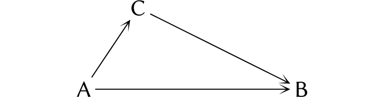

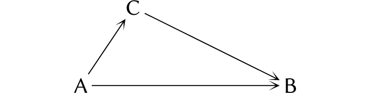

而在最佳情况下，C点位于从A到B的直线路程，此时从A到B的直线距离与从A到B且经过C的距离就是相同的。

At best, C was on the way from A to B anyway, and going via C made no difference.

（当然，你大概很难给你的出租车司机解释这些。）这个关于中途经过某地的情形在数学中被称为“三角不等式”，因为它与三角形的三边关系有关。这一次，这个三角形不再必须是一个直角三角形了。该规则看起来就像是毕达哥拉斯定理的一个弱化版本。

(You might have trouble trying to persuade a taxi driver of this, though.) This rule about stopping off on the way is called the “triangle inequality” because it’s about the edges of a triangle—not necessarily a right-angled one any more. It’s like a very puny version of the Pythagorean theorem.

**毕达哥拉斯：**是的！如果我们有一个直角三角形且已知其中两边的边长，我们就能精确计算出该直角三角形第三边的长度！

**Pythagoras:** Yes! If we have a right-angled triangle then we can work out the exact length of any side from the other two!

**三角形不等式：**呃，如果我们有一个非直角三角形的话，我们就知道“在最坏的情况下”第三边的长度等于另外两边之和。

**Triangle inequality:** Um, if we have a non-right-angled triangle then we know that the length of the third side will be *at worst* the sum of the other two.

这里所谓“最坏的情况”指的是“最长距离”（因为我们讨论的情境是出租车行驶距离），也就是说，如果三角形的三边分别是x、y和z的话，那么x最大可以是y+z。你可以想象在这种情况下，我们会得到一个极其平扁、细长的三角形，其中y边和z边将三角形向两边撑开，因此x边必须非常长才能与它们连接上。就像这样：

Here “worst” means “longest” (because we’re thinking taxis), so what we’re saying is that if the sides of the triangle are *x*, *y*, and *z* then the biggest *x* can be is *y* + *z*. You can imagine this as being an extremely long and thin triangle where the *y* and *z* edges have pretty much done the splits, so *x* has to be really long to accommodate them, like this:

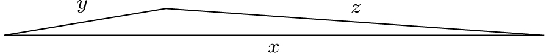

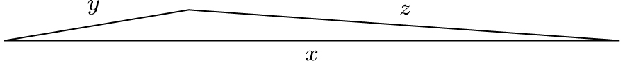

现在，让我们想象三角形的边是三个地点A、B和C之间的距离，这样我们就可以得到前面介绍的“中途经过点”的规则了。

Now if we think of the edges of that triangle as the distances between our three places A, B, and C then we get the “intermediate stopping place” rule from before.

就我个人而言，这个三角不等式有两点很有意思。第一点是，出租车行驶距离也遵循这个规则。第二个是，有一种非常常见的“距离”概念的实际应用情形并不遵循这个规则。第二点常常让我感到沮丧，这个情形就是火车票。

There are two curious things about this triangle inequality rule, I think. The first is that the taxi-distance still obeys this rule. The second is that there’s a perfectly common “distance-like” situation that does not, which is the cause of endless frustration to me: train tickets.

### 火车票Train Tickets

#### 对“距离”概念的继续推广Generalizing the Notion of Distance a Bit More

如果你在英国坐过很多次火车，你就会明白我的意思。有时候，当你想坐火车从A地去B地的时候，你会很气愤地发现，买两张先前往某个中间地点、再前往最终目的地的单程票的价格要低于买一张从A地到B地的直达火车票的价格。更让人觉得愚蠢的是，有时你甚至不需要另选一条路线，前往某个你本来不需要去的中间地点——你只需要把本来的行程分成两段，甚至不需要中间下车，就可以用更少的钱到达目的地。注意，这里我们讨论的不是A地到B地的距离，而是这段路程的票价。在一个理性的世界里，火车票价格应该遵循三角不等式——在从A地到B地的路途中经过另一地点C的行程票价不会低于直接从A地到B地的行程票价。但在实际生活中，它并不遵循这个规则，或者至少存在不遵循此规则的可能性。

If you’ve taken many trains around the United Kingdom you’ll know exactly what I mean. It’s the infuriating fact that sometimes, if you want to take a train from A to B, it’s cheaper to buy two tickets, going via some other place C. It’s particularly stupid because you don’t even have to take a different route—you just have to split the ticket in two. You don’t always even have to get off the train. Remember here we’re not thinking about the actual distance covered in going from A to B, but the *cost* of going from A to B. In a sensible world, this would obey the triangle inequality—it would not cost less to go via some other place C. But in reality it does or, at least, it can.

以从谢菲尔德到卡地夫为例。买一张从谢菲尔德到伯明翰的火车票和一张从伯明翰到卡地夫的火车票的总价格，要比直接买一张从谢菲尔德到卡地夫的火车票便宜。

For example, to go from Sheffield to Cardiff it can be cheaper to buy a ticket from Sheffield to Birmingham and a ticket from Birmingham to Cardiff.

而以从谢菲尔德到盖特威克为例的话，那么买一张从谢菲尔德到伦敦的火车票和一张从伦敦到盖特威克的火车票的总价格，要比直接买一张从谢菲尔德到盖特威克的火车票便宜。

To go from Sheffield to Gatwick it can be cheaper to buy a ticket from Sheffield to London and another from London to Gatwick.

或者，以从谢菲尔德到布里斯托为例的话，买一张从谢菲尔德到切尔滕纳姆的火车票和一张从切尔滕纳姆到布里斯托的火车票的总价格，要比直接买一张从谢菲尔德到布里斯托的火车票便宜。

To go from Sheffield to Bristol it can be cheaper to buy a ticket from Sheffield to Cheltenham and another from Cheltenham to Bristol.

除此以外，英国的火车票票价还有一些其他的奇怪现象，比如：

This is aside from the various other anomalies of UK train ticket prices, such as:

• 有时，头等舱比经济舱更便宜。

• Sometimes it’s cheaper to go first class than standard.

• 有时，行程越远反而越便宜，比如从伦敦到伊利要比从伦敦到剑桥的车票价格便宜，而剑桥实际上是从伦敦前往伊利途中的一站。

• Sometimes it’s cheaper to go further—for example, London–Ely can be cheaper than London–Cambridge even though the Ely train stops at Cambridge on the way.

• 有时，可全天使用的通票（可以在一天内的任何时候使用）反而比只能在非高峰时段使用的通票更便宜。

• Sometimes it’s cheaper to get a flexible ticket (where you can travel at any time of day) rather than one where you can only travel off-peak.

后面几个现象很难用之前我们提到的关于距离的三条规则来解释，因为它们更多受到价格和距离的关系或价格和时间的关系的影响，所以在这里我们暂且不去讨论它们。在数学中，我们通常会优先处理简单一些的问题，这并不是因为数学家都是胆小鬼，而是因为复杂的问题通常建立在简单问题的基础之上，所以我们必须先解决简单的问题。

These last points are harder to explain in relation to the three rules of distance, because they’re more to do with the interaction between cost and distance, or cost and time. So we’ll leave those for now. Often in mathematics we focus on the easier things first, not because we’re being wimps, but because the harder things are often built up from the easier things, and so we have to get the easier things right first.

要理解为什么设立某些规则，看看不遵守规则时会发生什么，往往很有帮助。为什么伦敦地铁里禁止饮酒？因为那曾经引发混乱。为什么地铁站里禁止吸烟？因为曾发生过造成死亡的严重火灾。这与理解事物背后的原理是一样的，而不是仅仅死记规则，或盲目照食谱的指令行事。

In order to see why rules are imposed, it’s often helpful to look at situations where they are *not* obeyed. Why is drinking alcohol not allowed on the Tube? Because it caused havoc. Why is smoking not allowed in Tube stations? Because there was a huge fire that killed people. This is similar to wanting to understand the principles behind things, rather than just memorizing the rules or blindly following instructions in a recipe.

现在，我们的三条关于距离的规则如下。

Now our three rules of distance are:

• 当A和B是同一个地点时，从A到B的距离为零。这也是从A到B距离为零的唯一可能的存在形式。

1. The distance from A to B is zero when A and B are the same place, and this is the *only* way the distance from A to B can be zero.

• 从A到B的距离等于从B到A的距离。

2. The distance from A to B is the same as the distance from B to A.

• 从A到B途径C的距离不可能短于从A到B的直线距离。

3. The distance from A to B can’t be made shorter by going via C.

以上就是我们总结出的一些关于距离的公理，而现在，我们要做人们在规则面前通常忍不住要做的事：试着打破规则。在数学里，打破规则的目的不是标榜叛逆，而是检验这个规则的有效性和应用边界。

Now that we’ve come up with a proposed list of axioms for the notion of distance, we’ll do what is often the temptation when presented with a list of rules: we’ll try to break them. The point of trying to break rules in mathematics is not to be arbitarily rebellious, but to test the strength and the boundaries of the world that we have set up.

我们已经看到了打破规则三（火车票）和规则二（单行道）的两个关于距离的实际案例，那么规则一呢？也许你认为打破规则一的实际案例是不存在的，但它的确存在。

We’ve seen distance-like situations that break rule 3 (train tickets) and 2 (one-way streets) but what about 1? You might think there’s no real situation that violates rule 1, but here is one.

### 网络约会Online Dating

#### 对“距离”概念的进一步推广Generalizing the Notion of Distance Yet Further

全球卫星定位系统（GPS）是一种神奇的技术。它的出现让我比以往更少迷路了，尤其是在坐公交车的时候，因为我可以在车上通过实时更新位置信息的手机地图跟踪自己的定位，然后奇迹般地在正确的站下车。

GPS is marvelous technology. It means I get lost a lot less than I used to, especially on buses, where I can follow my position along the map on my phone, and then miraculously get off the bus in the right place.

GPS也让网络约会变得快捷许多。在原先的慢速模式里，你可以通过对方公开的文字信息知道其是否与你在同一个城市，或者是否在你方圆100英里或200英里以内。而有了GPS以后，你可以直接看到对方此刻距你多少米远。我曾经看到过我的朋友在酒吧里使用手机约会软件（当然，只是为了好玩……），我切身感受到了看到某个你心仪的约会对象距离你很近，并且越来越近时的那种激动。“看，这个人距离我只有200米远……150米……50米——等等，难道他已经和我在同一个地方了？”

GPS has also made online dating rather immediate. In the old, slow model, you could see if someone lived in the same city as you, or within, say, 100 miles, or 200 miles. With GPS, you can see how many *feet* away this person is *right now*. I’ve watched friends of mine do this in bars (just for a laugh, of course. . .) and the excitement of seeing how close someone is is palpable, especially when they’re getting closer. “Ooh, this one is only 200 feet away. . . 150 feet away. . . 50 feet away—wait, doesn’t that mean he’s in here?”

然而，GPS显示的距离也可能与实际不符，因为它是根据卫星定位系统进行计算的，并没有考虑到你所在的位置距离地面的高度。我的一个朋友曾独自一人在酒店的房间里待着，然后很困惑地看到有很多有趣的聚会正在距离他“0米远”的地方举行。“可是，”他抱怨说，“我还是一个人待在酒店的房间里啊。”

However, this can cause great disappointment because the distances are based only on GPS, so they don’t take into account how far off the ground you are. A friend of mine was lonely in a hotel room somewhere and was perplexed at the number of interested parties who were supposedly “zero feet away.” “And yet,” he lamented, “Here I am alone in my hotel room.”

这也是一个关于距离的实际案例，而且它并不遵循规则一——当且仅当你与某人处在同一地点时，你与其距离为零。这个情境还有一些比网络约会更有意义的应用实例。比如，如果你遇到的与距离有关的问题并不是从A地走到B地，而是把某物从A地运到B地所需的能量呢？这样一来，如果A地就在B地的正上方，那么你就可以直接把东西扔下去，因而把东西从A地搬到B地所需要的能量就为0，尽管A地和B地并不是同一个地点。

This is an example of a distance-like notion that does not obey the first rule of distance—that you can only be zero distance away if you’re actually in the same place. This is also relevant to some situations that are slightly more useful than lamenting your online dating problems. For example, suppose your distance-like notion is not actually the distance from A to B, but the amount of energy you need to expend to transport something from A to B. Then if A is directly above B you can just drop it, so the energy used getting it from A to B is zero, even though A and B are not in the same place.

在数学里，关于距离的问题被称为度量问题。对于此类问题，还有一条无须言明的规则是：从A地到B地的距离不可能为负。然而，在某些情况下，甚至连这条规则都可能不再成立，比如，我们希望计算把东西从A地运到B地需要多少钱。而在现实中，你不但可能不需要自己出钱，甚至可能会有人付钱给你请你做这件事。欧洲商人会付钱给哥斯达黎加的咖啡农，请他们把他们的咖啡运到欧洲，然后从中提炼咖啡因。对于能量饮料的制造而言，这种原料十分宝贵。

A “distance-like notion” is called a *metric* in mathematics. There’s one more rule it has to satisfy that we didn’t bother mentioning: that the distance from A to B is never negative. There are even situations where it’s useful to relax this rule, such as if we’re studying how much it will cost to transport something from A to B. Not only might it cost you nothing (so the “distance” would be zero) but someone might even pay you to do it. Coffee growers in Costa Rica are *paid* to send their coffee to Europe to be decaffeinated, because the caffeine that is extracted is so valuable to the makers of energy drinks.

在数学中，考虑违背一条或几条关于度量的规则的情况，是一种对距离这个概念进行推广的有效方法。另一种方法则是将推广和抽象结合起来，该方法将引入“拓扑学”，这是我们本章后文会讨论的问题。

Relaxing one or more of the usual rules for metrics is one way to generalize the notion of distance in mathematics. A different way combines generalization with abstraction, and gives us the notion of *topology*, which we’ll look at later in this chapter.

### 三维的笔Three-Dimensional Pen

#### 通过增加维度来推广Generalizing by Adding Dimensions

我们刚刚已经看到，借助GPS技术实现网络约会的问题在于，GPS假设我们身处于一个二维世界。这种假设对于开车找路是有帮助的，但对于在摩天大楼里寻找潜在约会对象就不那么有帮助了，因为在这种情况下，第三个维度很重要。

The problem with using GPS for online dating, as we saw above, is that it assumes we’re only in a two-dimensional world. This usually works fine for finding your way around in a car, but not for finding a potential date inside a skyscraper, where the third dimension is rather important.

增加维度是数学推广的一种重要形式。有一个笑话是这么说的，如果你参加了一个数学研讨会，那么即便你什么也没听懂，你也可以提出一个听起来很像模像样的问题：“这可以推广到更高的维度吗？”。

Increasing the number of dimensions is an important form of mathematical generalization. There’s a joke that if you’re at a math research seminar you can ask an intelligent-sounding question even if you don’t understand anything, by saying, “Can this be generalized to higher dimensions?”

球面是圆形在更高维度上的推广，当然前提是你要用正确的方式看待圆形。让我们来想一想我们是怎么用圆规画圆的（虽然现在我们通常会直接借助电脑上的“画圆”程序来画）。首先，你要选择某个尺寸作为圆的半径，比如5厘米。然后，你需要将圆规一脚固定于圆的中心点位置，用活动的另一脚画出所有距离中心点5厘米的点。

A sphere is a higher-dimensional generalization of a circle, if you think about a circle in the right way. Let’s think about drawing a circle with a pair of compasses (although these days we all just draw circles by selecting a circle function on a computer). With compasses, you first choose a size (radius) for your circle, so let’s say you open the compasses to 5 cm. Then you fix the pointy tip on the page where the center of your circle will be, and then with the drawing end you essentially mark every point on the page that’s exactly 5 cm from the center.

现在假设你有一只可以在空中画图的笔（这是我一直梦想拥有的）。将这支笔作为圆规的一脚，然后用它来画出距离某个中心点5厘米的所有方向的点。你就得到了一个球面。

Now imagine you have a pen that can draw in midair, which is something I’ve always dreamed of. Then you could fix your compass point somewhere, and use your midair pen to mark every point in the air that was exactly 5 cm from your chosen center, *in all directions*. This would be a sphere.

数学家们很乐意就此把这个概念推广至四维、五维甚至更高维度的空间，虽然我们很可能并不知道更高维度的空间本身究竟意味着什么。根据这个概念的定义本身，一个四维空间中的半径为5厘米的球面就是“那个空间里所有距一个固定点的距离为5厘米的点”。因为这只是一个概念，而不是一个实物，所以我们知不知道它看起来是什么样子的并不重要。重要的只是这个概念本身是合理的。不过，对于一个概念而言，在某个方向上的推广是合理的并不意味着就不存在其他合理的推广方向了。

At this point mathematicians are perfectly happy to generalize this to four, five, or even more dimensions, although we don’t exactly know what that means. A sphere of radius 5 cm in 4-dimensional space is “all the points in that space that are exactly 5 cm from a fixed center.” Because it’s an *idea* rather than a physical object, it doesn’t matter that we don’t know what it looks like. It only matters that the idea makes sense. But just because one generalization makes sense doesn’t mean there aren’t others that make sense too.

### 甜甜圈Donut

#### 关于圆的不同推广A Different Generalization of a Circle

想象一个甜甜圈，一个环形的甜甜圈，如下图所示。

Imagine a donut. A ring donut.

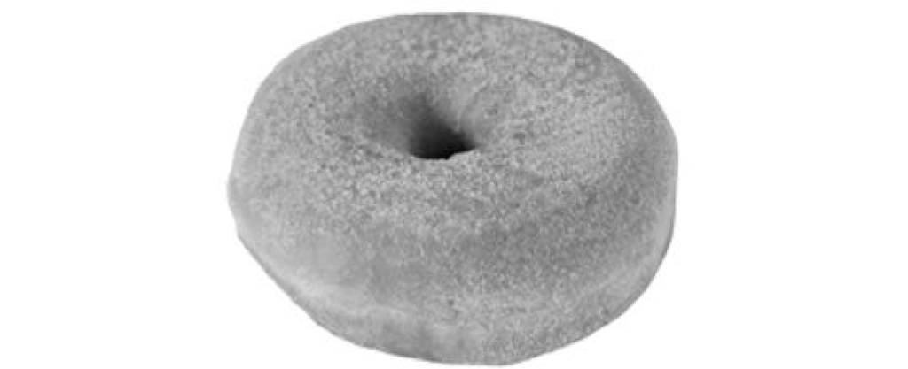

当数学家们说“甜甜圈”的时候，他们指的都是环形的甜甜圈——至少在他们讨论数学的时候是这样。也许他们该改口称其为“贝果面包”或面包圈。

When mathematicians say “donut” they always mean a ring donut at least when they’re talking about math. Perhaps they should start saying “bagel” instead.

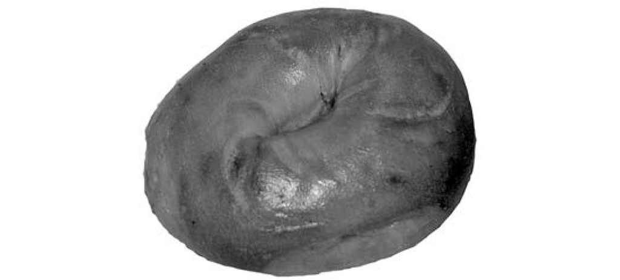

你可以怎样推广甜甜圈这个概念呢？最直接的办法是给它更多的洞，比如有两个洞的甜甜圈。

How would you generalize a bagel? The most obvious way is to give it more holes. A two-holed bagel!

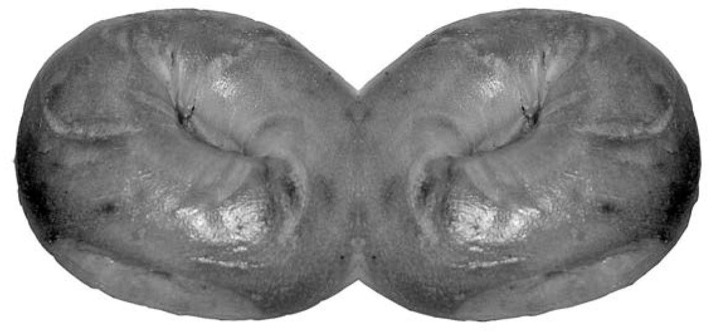

但我们还有另外一种推广的方式。在使用这种方式时，我们需要更仔细地看待我们的甜甜圈。当数学家们思考甜甜圈的时候，他们通常只是在讨论甜甜圈的表面，而不是实心的甜甜圈。类似地，当他们说“球”的时候通常指的只是球面，就像只考虑橙子的表皮而非整个橙子。一个球面就像一个气球，它的内部是空的。

But there is another way to generalize it. For this we have to be a bit more careful about this bagel/donut of ours. When mathematicians think about donuts they’re usually only thinking about the *surface* of the donut, not the solid donut. Just like when they say “sphere” they only mean the surface of the ball, like the skin of an orange, not the whole orange. A sphere is like a balloon, with empty space on the inside.

甜甜圈也是如此。想象一下用魔法把一卷卫生纸转化为一个可随意拉伸的橡胶材质的圆筒，然后把它弯成一个圆圆的环。或者，想象一下把一个彩虹圈弯成一个圆，头尾相接，如下图所示。它看起来和一个环形甜甜圈很像，只不过它是中空的。

Likewise for donuts. Perhaps you can imagine taking a rubber tube and bending it round into a hoop. Or perhaps imagine taking a Slinky and bending it round so that the ends meet up. It will look like a donut, but be hollow.

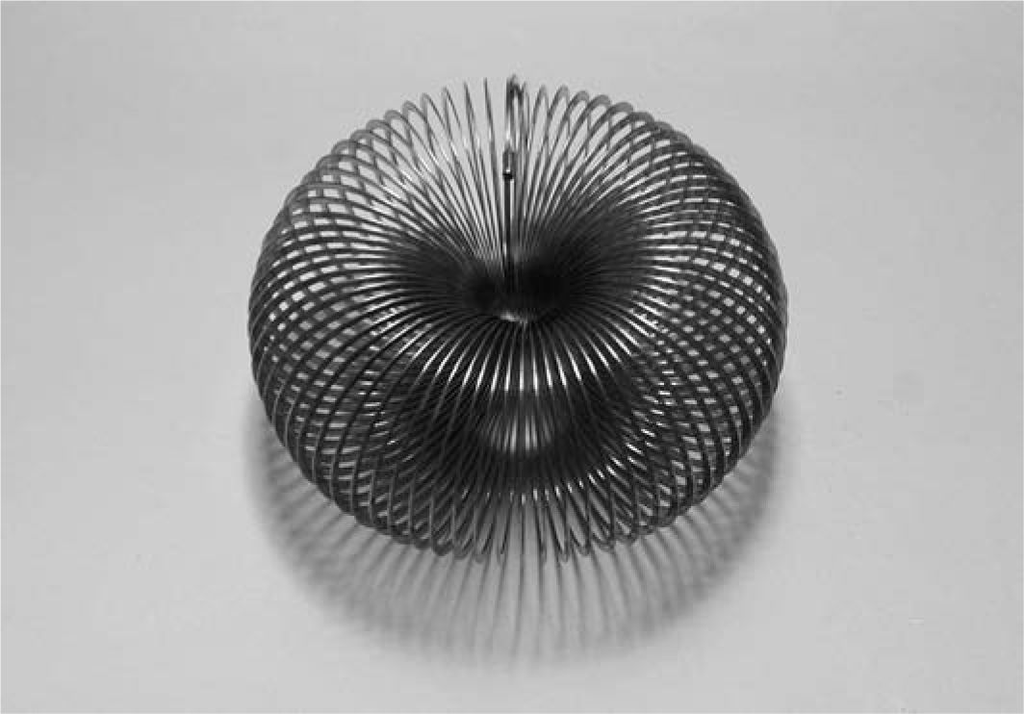

它的数学名称叫作“环面”（torus）。

This is technically called a *torus*.

现在让我们回顾一下我们是如何把一卷卫生纸变成一个环面的。或者，你也可以想象用泡泡制作一个类似的形状：用一个沾着足够多泡泡液的大的泡泡棒在空气中拖出一个大泡泡——不是用嘴吹，而是边走边拖泡泡棒，在绕了一个圈之后，这个泡泡环就能头尾相接了。它的样子看起来就像一个大型甜甜圈——一个空心的甜甜圈，一个空心的泡泡甜甜圈。

Now, let’s think about how we made it from a tube. You could also imagine trying to make it out of soap bubble—the kind you make by dipping a big hoop in bubble liquid and waving it in the air. Imagine taking this hoop and dragging it through the air for a while—you make a sort of bubble tube as you go. Now imagine dragging it in a big circle so that it comes back to meet itself. It will be like a donut—a hollow donut. A hollow bubble donut.

我们通过在空中以圆形轨迹拖泡泡棒得到了这个环面，这也说明环面是圆形的一种推广——我们所做的不过是改用泡泡棒而非画笔在空中画圆。现在，进一步对环面这个概念进行推广可能就会变得有些奇怪了。想象一下拖着一整个甜甜圈在空中画出圆的轨迹。你很难想象它的样子，因为它并不适合三维空间，但至少你大概可以想象得到它绝对不是一个两个洞的甜甜圈。

We made this by dragging a hoop through the air in a circle, which shows that the torus is a generalization of a circle—all we’ve done is draw in the air with a hoop instead of a midair pen. Now, for the generalization of the torus things are going to get a bit weird. Imagine dragging *an entire donut* through the air in a circle. It’s pretty difficult to imagine what this looks like, because it doesn’t really fit into three-dimensional space, but perhaps you can at least imagine that it’s definitely not the same as a two-holed donut.

### 概括性陈述Sweeping Statements

#### 另一种推广方式A Different Kind of Generalization

“英国总是下雨。”

*It always rains in England.*

“火车从不准时。”

*The trains never run on time.*

“看歌剧很贵。”

*Opera is really expensive.*

“你总是那么说。”

*You always say that.*

这些都是概括性陈述的例子，也属于推广的一类。不过，这种推广方式与你把一个普通甜甜圈变成一个有两个洞的甜甜圈不同。这种推广更多的不是放宽一些条件让更多的符合者进来，而是暂时忽略一些没那么重要的因素，聚焦于核心属性。

These are all *sweeping statements*, or generalizations. But they’re different from the kind of generalization where you turn a bagel into a two-holed bagel. This kind is not about relaxing conditions to allow more people in, but is more like ignoring outlying cases temporarily, to focus on the central part of the bell curve.

当然，这些概括性陈述并不是完全正确的：火车偶尔也会准时；英国总有不下雨的时候；你可以很容易在伦敦买到10英镑以下的歌剧票；你也不是“总是那么说”（不管那具体是什么），只是在特定情况下才会那样说。问题是，这些例外重要吗？我们主要研究的是例外情况还是通常情况下的行为？

Of course, these sweeping statements aren’t *entirely* true. Occasionally, trains do run on time. And sometimes it stops raining in England. And you can easily get opera tickets in London for under ten pounds. And you don’t really say “that” (whatever that is) all the time, just in certain situations. The question is, do these exceptions matter? Do we study exceptions, or do we study the main body of behavior?

答案是，我们两者都研究。我们不可能只研究一个而不管另一个。从例外情况中，我们可以学到很多有趣的东西，即使那些例外情况很罕见，并且没那么有代表性。而如果我们不研究常规情况，我们又如何知道某种情况是反常的呢？这就需要我们暂时忽略特殊情况了。

The answer, surely, is both. And, more to the point, we can’t really study one without studying the other. There are interesting things to be learned from the extremities of behavior, even if those extremities are rare, so not at all representative. But how can we know in what way something is unusual if we don’t also study what is usual? That involves temporarily ignoring the extremities.

### 甜甜圈和咖啡杯Bagels, Donuts, and Coffee Cups

#### 拓扑学入门An Introduction to Topology

结合我们之前关于距离问题和甜甜圈的讨论，我们便来到了数学的一个名叫“拓扑学”的分支，它研究的是事物的形状。我们已经讨论过多种关于距离概念的推广方式，由此我们得到了很多类似距离，但又并不完全符合距离概念的所有规则的事物。

Combining our previous discussions about distances and bagels brings us to a branch of mathematics called Topology, which studies the shapes of things. We’ve already seen ways of generalizing the notion of “distance” so that we have something a bit like distance, but not necessarily satisfying all of the usual rules that distance does.

现在，我们可以更进一步推广这个概念了，因为有时候我们并不关心两个事物的距离究竟有多远，而只想知道我们能不能从一地去到另一地，以及怎么去。如果你住在英格兰南面的话，怀特岛也许离你比苏格兰更近，但事实上你并不能直接开车过去——这完全是另外一种麻烦。

But now we can generalize this even more, because there are times when we don’t mind so much exactly how far apart two things are, but only whether we can get from one point to the other, and how. If you live in the south of England, the Isle of Wight is probably closer than Scotland, but the fact is that you can’t just drive there—so it’s a whole different kind of hassle.

同样的问题在城市街区也是存在的。比如在芝加哥这样的城市里，你可能突然就从一个街区来到了另一个街区，虽然实际上你只过了一条马路——整个路程很短，但你已经来到了一个不同的街区。

Something similar can happen with neighborhoods of a city. Some cities, like Chicago, can change rather abruptly from one block to the next, where one neighborhood ends and another begins. It doesn’t matter that you’ve only traveled one street over—the distance is very small, but you’ve gone into a completely different neighborhood.

不关心距离也就意味着不关心尺寸，就像相似三角形一样，以下这些圆形也可被视为“相同”：

When we don’t care about distance it means we also don’t care about size, just like with the similar triangles, so all these are “the same.”

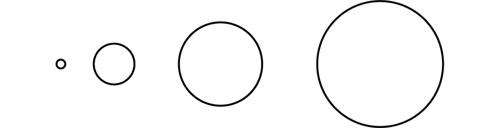

另外一个我们并不太关心的问题是曲率。所以下面这两个形状也可被视为“相同”：

Another related thing we might not worry about is *curvature*, so these two shapes also count as “the same”:

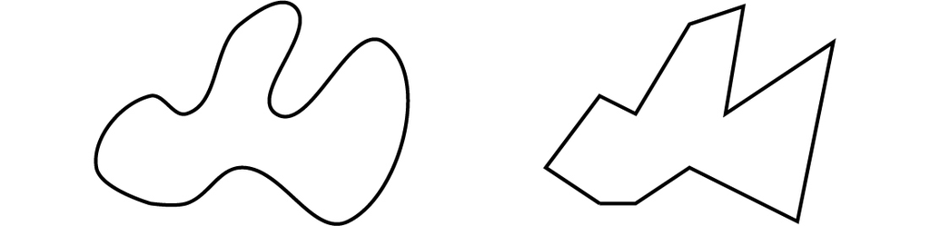

我们现在只关心一个东西有多少个洞。所以在我们现在讨论的体系里，不仅所有的三角形是“相同”的，而且三角形和正方形、圆形也是“相同”的：他们都属于只有一个洞的形状。相比之下，数字8则属于完全不同的另一种形状，因为它有两个洞。

In fact, the only thing we’re really worried about is the number of holes something has. So now we have a system under which not only are all triangles “the same,” but triangles are also “the same” as squares and circles: they’re all shapes with one hole. However a figure 8 is “different” because it has two holes.

思考这个问题的一种方法是想象所有东西都是用橡皮泥做的：想象一下你能否将一个形状捏成另一个形状，同时保证不制造出新的洞，也不需要将其他的形状粘在它上面。

One way to think about this is to imagine that everything is made of plasticine or playdough, and you want to know if you can bend one shape into another without making any new holes or sticking anything together.

**问题：**字母表里的哪些大写字母在这个形状可塑的情境下是“相同”的？

**Question:** Which capital letters of the alphabet are “the same” in this bendy sense?

• 没有洞的字母：C E F G H I J K L M N S T U V W X Y Z。

• There are letters with no holes: C E F G H I J K L M N S T U V W X Y Z

• 有一个洞的字母：A D O P Q R。

• There are letters with one hole: A D O P Q R

• 唯一一个有两个洞的字母：B。

• There is just one letter with two holes: B

这说明，从拓扑学的角度讲，大部分字母都是一样的。这也正是电脑很难识别手写字母的原因之一。

What this says is that *topologically* almost all letters are the same. This is one of the reasons that computer recognition of handwriting is so hard.

我们也可以尝试在更高的维度讨论这个问题。想象一下我们用一团橡皮泥做出一个甜甜圈。我们有两种制作方法：你可以先捏出一个香肠的形状，然后把它的头尾相连，也可以在揉成一团的橡皮泥中间戳一个洞。不管使用哪种方法，你的做法都证明了从拓扑学的角度来看，甜甜圈和一团橡皮泥是不同的。而当你做好了甜甜圈以后，你不必戳新的洞也不必粘上另一块橡皮泥就可以用它做出一个咖啡杯。甜甜圈的洞可以被视为咖啡杯把手与杯身之间的那个洞，你只需要把实心的部分捏出凹面做成杯肚的形状，咖啡杯就做成了。也就是说：

We can also try this in higher dimensions. Imagine trying to make a bagel (a solid one, not a hollow one) out of a lump of playdough. There are basically two ways of doing it: you could either make a sausage shape and stick the ends together, or you could poke a hole in the lump. Either way, you’ve done something that shows that a bagel is not topologically the same as a plain lump. However, once you have your bagel/donut shape, you can make a coffee cup *without* making any new holes or sticking anything together. The donut’s hole can turn into the handle of the coffee cup, and then you just need to squash an indentation in the rest of it to make the cup part. What this says is:

从拓扑学的角度讲，甜甜圈和咖啡杯是一样的。

*Topologically, a bagel is the same as a coffee cup.*

而与此相对，我们之前提到的“两个洞的甜甜圈”则与一个洞的甜甜圈或者咖啡杯完全不同。关于事物在拓扑学上的异同这个问题有很多应用。比如，之前我们讨论过关于绳结的数学，而绳结是拓扑学研究的一类对象。在借助拓扑学研究绳结的过程中，一个很奇妙的思考方式就是，你并不是在空白的纸上用彩色画笔画画，而是先用彩色画笔涂满一整张纸，然后擦掉你想擦的部分，以此完成一张主体部分为白色而背景为彩色的画。现在，让我们想象一下在三维空间里进行这样的创作。

However, the “two-holed bagel” pictured earlier is definitely different. The study of which things are topologically the same and which are different has many applications. For example, we talked about the mathematics of knots earlier on, and these are studied using topology. The amazing idea here is like the kind of drawing where instead of drawing on a blank page, you color in an entire page and then erase parts to make a picture in white. Now we’ll imagine doing this in three dimensions.

想象一下你拿着一支“可以在空中画画的彩色笔”，你将一个盒子的内部空间填满了颜色。然后，你又拿出一个“可以在空中使用的橡皮擦”，用它在你刚才填色的部分擦出一个绳结的形状。现在，整个空间剩下的彩色部分就是一个几乎无法想象，却很容易用数学方法进行研究的形状。

Imagine your midair pen again, and imagine that you have “colored in” the whole inside space of a box. Now you take a “midair eraser” and erase a knot from what you colored in. What is left is something with a curious shape that’s almost impossible to imagine, but very handy to study mathematically.

### 一次对想象力的挑战A Challenge for Your Imagination

我们刚才描述的那种在三维空间里去掉某物的过程叫作取“补集”。一旦我们完成了这个过程，我们就可以像捏橡皮泥一样任意改变剩下那部分的形状，前提是不增加洞的数量或者粘上另一块橡皮泥。你能想象出下面这些形状的补集吗？

The process of erasing something in three dimensions that we just described is called taking the *complement*. Once we’ve done it, we can imagine that we are allowed to squash what’s left just as if it were playdough, again without making any new holes or sticking things together. Can you imagine the following complements?

• 一个圆圈○在拓扑学上的补集与一个空心的、内部中央只撑了一根短棍的球面相同：

• The complement of a circle is topologically the same as a sphere with a bar stuck across the middle of its empty insides:

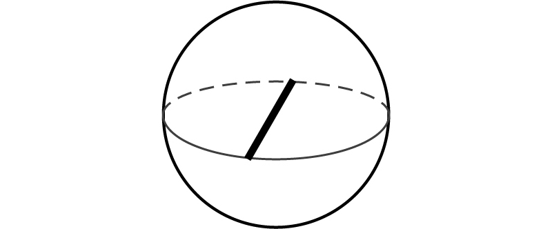

• 两个互相扣在一起的圆环的补集

• The complement of two interlocking circles

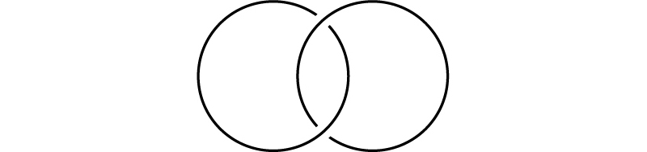

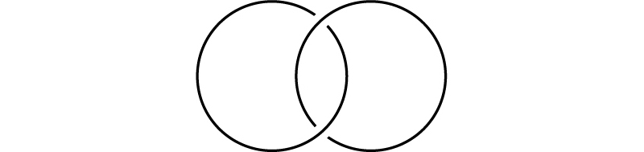

在拓扑意义上，与一个内侧附有环面、环面位于空腔中的球面相同：

is topologically the same as a sphere with a torus stuck on the inside of the surface, in the empty space:

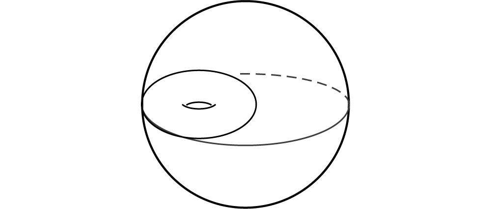

这还是一些很简单的形状，但是已经很难直观地想象出来了。数学的强大之处就在于它使得我们不需要真正将某个概念想象成实物就可以对问题进行严谨的研究。

Those were only very simple shapes, and already it’s very hard to imagine them in your head. The power of mathematics is that it enables us to study these things rigorously without having to imagine them at all.

另外一个例子是关于用纸剪下某个平面形状然后将它们粘成一个三维的图形。你也许还记得如何用一张纸折成一个正方体：

Here’s another example, involving cutting out shapes and sticking the sides together to make something three-dimensional. You may remember how to make a cube starting from a flat shape.

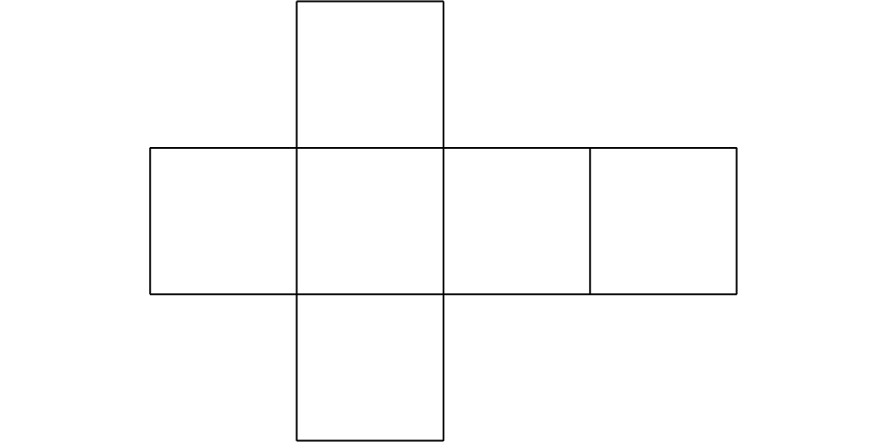

如果你将这个形状沿着外围轮廓剪下来，然后沿各条线折叠，你就可以把重合的边粘起来得到一个正方体。或者，你也可以试试将下面这个图形折成三维图形：

If you cut this out and fold it along the lines, you can stick the edges together to make a cube. If you try it with this one

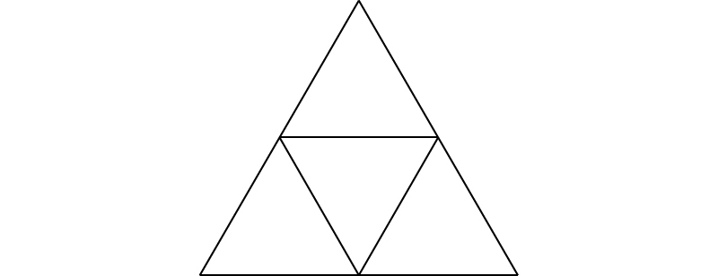

你会得到一个三角形的金字塔，它的数学名称叫作“四面体”。

you will get a triangular pyramid that is technically called a *tetrahedron*.

现在，请想象一下用可以任意塑形的橡皮泥片代替纸做同样的事情。这样一来，我们就可以用下图所示的正方形橡皮泥片制作甜甜圈（环面）了——我们要确保把标为A的边都粘在一起，使箭头的方向保持一致，对于标为B的边也进行一样的操作：

Now imagine that you have some bendy playdough paper. Now we can make a bagel/donut/torus out of a square like this—here we have to make sure we stick the edges labeled A to one another, with the arrows matching up, and likewise the edges labeled B:

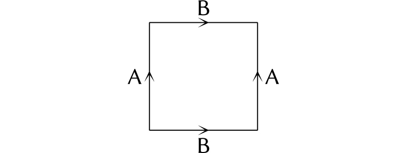

你完成了吗？接下来是真正的挑战。遵循刚刚的操作规则，即将字母相同的边粘起来且确保箭头方向一致，你能想象出用下面这个八边形橡皮泥片折成的立体图形会是什么形状吗？

Now here’s a serious challenge. Can you imagine what shape you’ll get if you cut out this octagon and stick it together according to the labels?

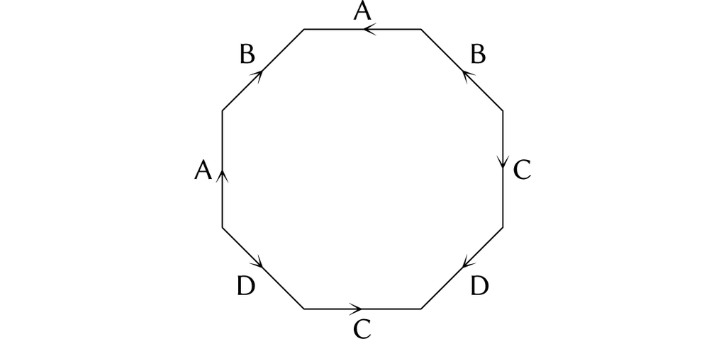

答案是：有两个洞的甜甜圈。

The answer is: a *two-holed bagel*.

现在，你可以将此推广至有更多洞的甜甜圈——试图凭大脑想象出最终的图形是很难的，但拓扑学给了我们一种可以严谨地研究这些关于比我们能够想象出的图形复杂得多的图形的问题的方法。

Now imagine trying to generalize this for even more holes. It’s pretty hopeless to try and do this in your head, but topology gives us a way of studying these things rigorously, for shapes much harder than those that our imaginations can ever visualize.

### 一个推广游戏A Generalization Game

下面这些形状有什么共性？  
正方形、梯形、菱形、四边形、平行四边形

What do the following shapes have in common?

正方形、梯形、菱形、四边形、平行四边形

square, trapezoid, rhombus, quadrilateral, parallelogram

答案是它们都有四条边。你能把它们按照概括性程度的高低依次排列吗？从前一个图形到后一个图形，推广的方式又是怎样的？

The answer is that they all have four sides. Now can you see how to arrange them in order of *increasing* generality? And what is the process of generalization to go from each one to the next?

答案是：

The answer is:

按照概括性从低到高，图形正确的排列顺序是：  
正方形、菱形、平行四边形、梯形、四边形

square, rhombus, parallelogram, trapezoid, quadrilateral

推广过程是这样的：

The processes of generalization are like this:

• 正方形的四条边相等，四个内角也相等。

• A square has all four sides the same length, and all four angles the same.

• 菱形的四条边相等，所以从正方形到菱形的推广过程是允许四个内角的度数不同。不过，相对的两个内角度数必须相等，因为四条边的长度相等。

• A rhombus only has all four sides the same, so the step of generalization is to allow the angles to be different. However, they will be forced to be in pairs—the angles opposite one another have to be the same as one another just because the sides are all the same length.

• 平行四边形类似于菱形，但只要求两组对边各自等长。这里没有对角度作进一步的推广：两组对角仍然必须分别相等。注意，正是因为对角相等，两组对边才必然分别平行。

• A parallelogram is like a rhombus but now only the sides opposite one another have to be the same length. There’s no generalization regarding the angles, which will still be forced to be the same in opposite pairs. Note that opposite sides are forced to be parallel, because of the opposite angles being the same.

• 梯形的唯一要求是有两条相对的边平行，没有关于边长的限制或者角的限制，它们可以都不相同。

• A trapezoid only has the condition that one pair of opposite sides has to be parallel. So there’s no longer any condition on the lengths of the sides or the sizes of the angles. They can now all be different.

• 四边形是有四条边的任意图形。在这里，我们进一步去掉了有两条相对的边平行这个条件。

• A quadrilateral is any old shape with four sides, so in this step we have generalized by dropping the condition that one pair of sides has to be parallel.

在这个例子里，我们看到推广的每一步都是去掉了前一个图形定义中的一个限定条件，使得更多的图形符合新的定义。适当放宽条件是数学推广的一种常见方式。

In this example we can see that each step of generalization occurred by dropping some conditions on the shape in question, so that more shapes were allowed into the picture. Relaxing conditions slightly is one of the common ways of performing a generalization in math.

You might have noticed that there’s another possible step in this generalization, via another type of four-sided shape that we didn’t mention above: the rectangle. A rectangle is a different way of generalizing a square—where a rhombus still has the same lengths of sides, but possibly different angles, a rectangle has the same angles, but possibly different lengths of sides. When we relax rules one by one, we get different routes to generalization depending on the order in which we relax the rules. Generalization is not an automatic process. There are always different possible generalizations depending not just on how far you go, but on what point of view you take. This is one of the reasons mathematics as a subject keeps growing at an ever-increasing rate, as each generalization gives rise to a multitude of others.

## 6 内在和外在Chapter 6 Internal vs. External

### 巧克力梅干面包布丁Chocolate and prune bread pudding

#### 配料Ingredients

10 盎司去皮的陈面包

10 oz. stale bread, without crusts

2 个鸡蛋

2 eggs

3 盎司红糖

3 oz. brown sugar

4 盎司黑巧克力

4 oz. dark chocolate

14 盎司切碎的梅干

14 oz. chopped prunes

2 盎司融化的黄油

2 oz. melted butter

#### 做法Method

1. 将面包掰成小块，用食品加工机打成面包屑。

1. Break the bread into small pieces and make it into bread crumbs in a food processor.

2. 将鸡蛋与糖打匀，把巧克力放入牛奶中缓缓加热融化，再混入蛋液。

2. Beat the eggs and the sugar, melt the chocolate gently with the milk, and mix it into the eggs.

3. 把混合液倒入装有面包屑和梅干的大碗中，浸泡几小时。

3. Pour over the bread and prunes in a large bowl, and leave it to soak for a few hours.

4. 拌入融化的黄油，倒入铺好烘焙纸的 8 英寸方形蛋糕模，以 350°F 烘烤 45 分钟，或烤至凝固、表面略脆。

4. Mix in the melted butter, then bake in an 8-inch square cake pan lined with parchment, at 350°F for 45 minutes or until set and slightly crispy on top.

5. 趁温热配巧克力酱食用。

5. Serve warm with chocolate sauce.

上面这个巧克力梅干面包奶油布丁的食谱是我在某年做了圣诞节布丁之后发明出来的。我当时有一些陈面包（我通常不直接吃面包，而且由于我把面包边都切掉了，所以它们变得又干又硬）和梅子干（同样，一旦打开过包装，它们很快就变得像石头一样硬了），当然，还有很多巧克力，这是我家的常备品。

I came up with this recipe for chocolate and prune bread pudding after making Christmas pudding one year (the English kind, which resembles a dark, sticky fruit cake). I had leftover bread (which had gone stale because I’d cut the crusts off) and prunes (which quickly go rock hard once you’ve opened the bag). And of course I always have plenty of chocolate in the house.

我们节俭的祖先用剩菜发明了很多食谱。农舍派和牧羊人派是为了把周日午餐聚会剩下的烤肉消灭掉而发明的，面包奶油布丁和法式吐司［或者按照法国人的叫法是pain perdu，按字面意思就是“丢掉的（或浪费掉的）面包”］是为了消灭陈面包而发明的用牛奶和鸡蛋软化它的食谱。中国人也有一个类似的发明，即蛋炒饭，具体而言就是用蛋液翻炒前一天剩下的米饭使其软化。过熟的香蕉可以做成美味的香蕉蛋糕。此外，每个人都有他们自己的消灭圣诞节后大量剩余的火鸡肉的方法——火鸡咖喱？火鸡派？我本人最喜欢的是我妈妈做的花生酱火鸡意面沙拉。

There are many dishes invented by our more frugal ancestors for using up leftovers. Cottage pie and shepherd’s pie use up leftover roast meat from Sunday lunch. Bread pudding and French toast (or, as the French call it, “pain perdu,” which translates literally as lost, or wasted, bread) make use of stale bread by softening it up in egg and milk. There’s the Chinese version, where leftover rice is similarly fried with egg to soften it up again. Overripe bananas can be made into delicious banana bread. And everyone has their favorite dish to make out of the mountains of leftover turkey that are somewhat inevitable after holidays. Curry? Pie? My favorite was my mother’s turkey spaghetti salad with peanut sauce. In all these cases you’re sort of doing things the wrong way round if you go and and deliberately look for the ingredients to make a dish that was supposed to use up leftovers.

在所有这些例子里，如果你刻意地寻找食材来做本该用剩余食物做的菜的话，你就本末倒置了。其实对于普通的食谱也一样，就像我们在第一章提到的：你可以选择一个食谱，然后根据食谱去购买所需的原材料，或者，你也可以在逛超市的时候买一些自己感兴趣的食材，看看你能发明出什么新菜品。  
我认为，这些例子阐释了内在动机和外在动机的区别。如果你先选定了一个菜谱，那么按照它来买菜做饭就是一个出于外在动机的行动；如果你决定使用已有的原材料做饭，那么这就是一个出于内在动机的行动。还有一些时候，你已经有了一个大致的计划，但你决定边做边创造，看看自己最终究竟会做出什么。如果你做出了你本来计划做的东西，那么你的内在动机和外在动机就完美统一了。另一些时候，你做出来的东西和你的预期完全不同，但可能同样很棒。或者，你可能本来并没有什么具体的预期，但最终的成品一样很好（就像我第一次在无意中做出了无麸质巧克力能量棒一样）。对于最后一种情况，我们可以称为“幸运的意外”。这种情况与内在动机和外在动机的统一不一样。

There’s a similar issue even if you’re deliberately making a dish from new ingredients, as we mentioned in Chapter 1: you could pick a recipe and go shopping for the ingredients you need, or you could buy some ingredients that look interesting, and invent something with them. All this illustrates the difference between what I call *internal* and *external* motivation. If you set out with a recipe in mind, this is an external motivation. If you make something up from the ingredients you have, it’s an internal motivation. Sometimes you set out with something in mind, but make it up as you go along to see what will happen. If it then matches up with whatever you had in mind to make, your internal and external motivations have gloriously come together. Sometimes things turn out completely differently from how you were expecting them but are still fantastic. Or maybe you had no idea what to expect at all (like when I first tried making raw chocolate energy bars) but it’s fantastic anyway. This is what we might call a happy accident. That is different from the internal and the external matching up.

有趣的是，在厨房里，我更多地受到外在动机的驱使。而在数学里，我主要受内在动机的驱使。

Funnily enough, in the kitchen I’m much more externally motivated. In math, I’m very internally motivated.

或者，你被要求通过各种方法使这些数字得到一个既定的数字，比如952。数学家詹姆士·马丁在几年前的一期智力问答节目里就做到了这件事（令人惊叹！）：

Or if you were actually on *Countdown*, you might try to use these numbers to make a given number, say, 952, like the mathematician James Martin did rather spectacularly some years ago, as follows:

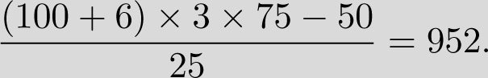

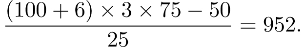

这就是一种外在动机，你可以随便使用什么方法，只要你能达到某个特定的目标。

That was like *external* motivation, where you try to build something specific in whatever way you can.